# Data Analysis of ride Share

Ganesh

2024-08-21

#1. Introduction

##This report presents an analysis of ride-sharing data collected between August 2023 and July 2024. The main objective is to compare the riding patterns of members and casual users, focusing on metrics such as ride length, total rides by weekday, and ride length by month.

#2. Data Preparation

##2.1 Loading Required Libraries

```r
library(tidyverse)
library(lubridate)
library(janitor)
library(skimr)
library(readr)
```

##2.2 Importing Data

```r
df1 <- read.csv("C:/Users/Vd Ganesh/Desktop/Google case study/aug_2023_trip.csv")
df2 <- read.csv("C:/Users/Vd Ganesh/Desktop/Google case study/sep_2023_trip.csv")
df3 <- read.csv("C:/Users/Vd Ganesh/Desktop/Google case study/oct_2023_trip.csv")
df4 <- read.csv("C:/Users/Vd Ganesh/Desktop/Google case study/nov_2023_trip.csv")
df5 <- read.csv("C:/Users/Vd Ganesh/Desktop/Google case study/dec_2023_trip.csv")
df6 <- read.csv("C:/Users/Vd Ganesh/Desktop/Google case study/jan_2024_trip.csv")
df7 <- read.csv("C:/Users/Vd Ganesh/Desktop/Google case study/feb_2024_trip.csv")
df8 <- read.csv("C:/Users/Vd Ganesh/Desktop/Google case study/mar_2024_trip.csv")
df9 <- read.csv("C:/Users/Vd Ganesh/Desktop/Google case study/apr_2024_trip.csv")
df10 <- read.csv("C:/Users/Vd Ganesh/Desktop/Google case study/may_2024_trip.csv")
df11 <- read.csv("C:/Users/Vd Ganesh/Desktop/Google case study/jun_2024_trip.csv")
df12 <- read.csv("C:/Users/Vd Ganesh/Desktop/Google case study/july_2024_trip.csv")

df_all <- rbind(df1, df2, df3, df4, df5, df6, df7, df8, df9, df10, df11, df12)
```

##2.3 Data Cleaning

```r
df_all <- df_all %>%
  drop_na() %>%       #Remove rows with missing data
  distinct() %>%      #Remove duplicate rows
  select(-start_lat, -start_lng, -end_lat, -end_lng) #Remove specific columns

#Convert date-time columns to POSIXct format
df_all$started_at <- as.POSIXct(df_all$started_at, format = "%Y-%m-%d %H:%M:%S")
df_all$ended_at <- as.POSIXct(df_all$ended_at, format = "%Y-%m-%d %H:%M:%S")

#Add weekday number
df_all$weekday_number <- wday(df_all$started_at)

# Add other time-related columns
df_all <- df_all %>%
  mutate(
    weekday_name = wday(started_at, label = TRUE),
    year = year(started_at),
    month = month(started_at, label = TRUE),
    year_month = paste(year, month, sep = " ")
  )
```

#3. Key Metrics

## 3.1 Ride Length Calculation

```r
df_all$ride_length <- difftime(df_all$ended_at, df_all$started_at, units = "mins")
```

##3.2 Summary Statistics by Membership Type

```r
summary_data <- df_all %>%
  group_by(member_casual) %>%
  summarise(mean_ride_length = mean(ride_length, na.rm = TRUE))
```

#4. Analysis ## 4.1 Mean Ride Length by Membership Type

```
## Defaulting to continuous.
```

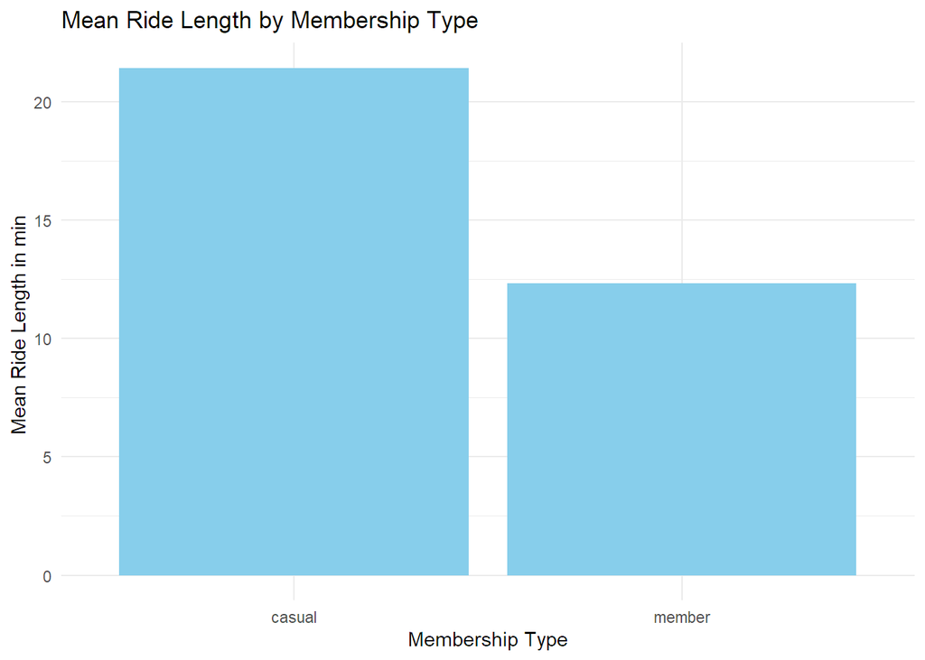

```r
ggplot(summary_data, aes(x = member_casual, y = mean_ride_length)) +
  geom_bar(stat = "identity", fill = "skyblue") +
  labs(title = "Mean Ride Length by Membership Type",
       x = "Membership Type",
       y = "Mean Ride Length in min ") +
  theme_minimal()
```

##4.2 Total Rides by Weekday Number

```r
rides_by_weekday_number <- df_all %>%
  group_by(weekday_number, member_casual) %>%
  summarise(ride_length = n()) %>%
  arrange(weekday_number)
```

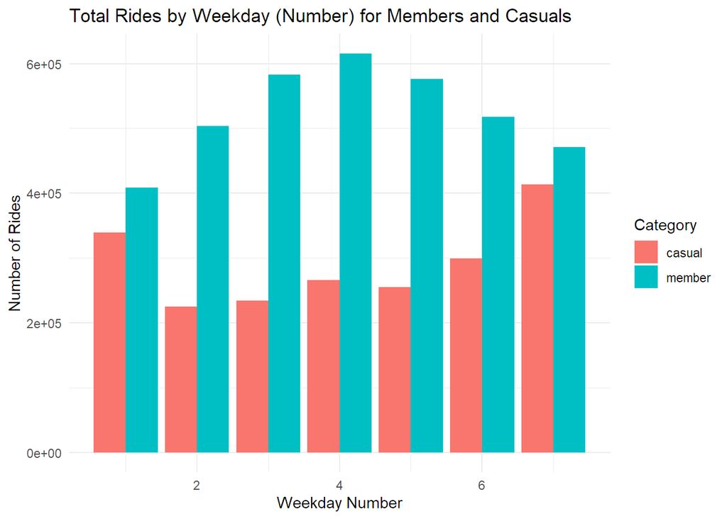

```r
ggplot(rides_by_weekday_number, aes(x = weekday_number, y = ride_length, fill = member_casual)) +
  geom_bar(stat = "identity", position = "dodge") +
  labs(title = "Total Rides by Weekday (Number) for Members and Casuals",
       x = "Weekday Number",
       y = "Number of Rides",
       fill = "Category") +
  theme_minimal()
```

##4.3 Mean Ride Length by Weekday

```r
mean_rides <- df_all %>%
  group_by(weekday_number, member_casual) %>%
  summarise(mean_ride_length = mean(ride_length, na.rm = TRUE)) %>%
  ungroup()
```

```
## Defaulting to continuous.
```

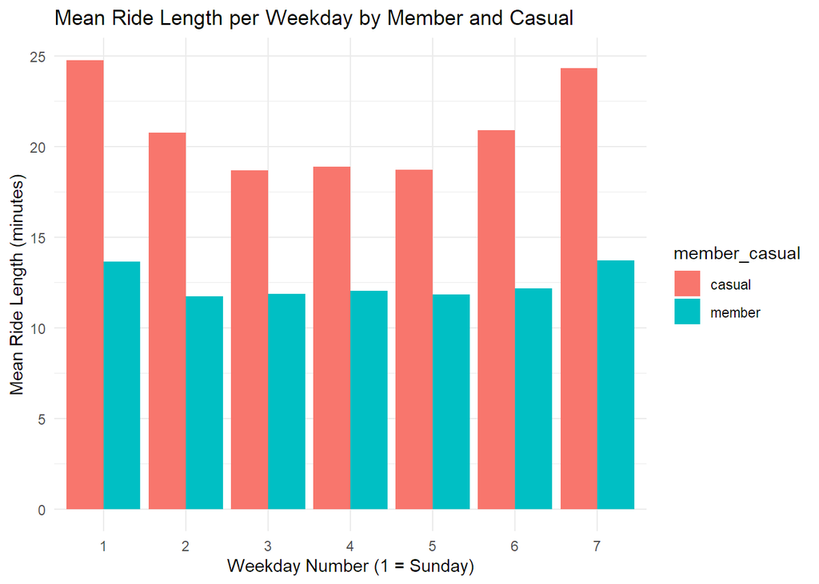

```r
ggplot(mean_rides, aes(x = factor(weekday_number), y = mean_ride_length, fill = member_casual)) +
  geom_bar(stat = "identity", position = "dodge") +
  labs(x = "Weekday Number (1 = Sunday)", y = "Mean Ride Length (minutes)",
       title = "Mean Ride Length per Weekday by Member and Casual") +
  theme_minimal()
```

##4.4 Mean Ride Length by Month

```r
summary_by_ym <- df_all %>%
  group_by(member_casual, year_month) %>%
  summarize(mean_rides = mean(ride_length))
```

```
## Defaulting to continuous.
```

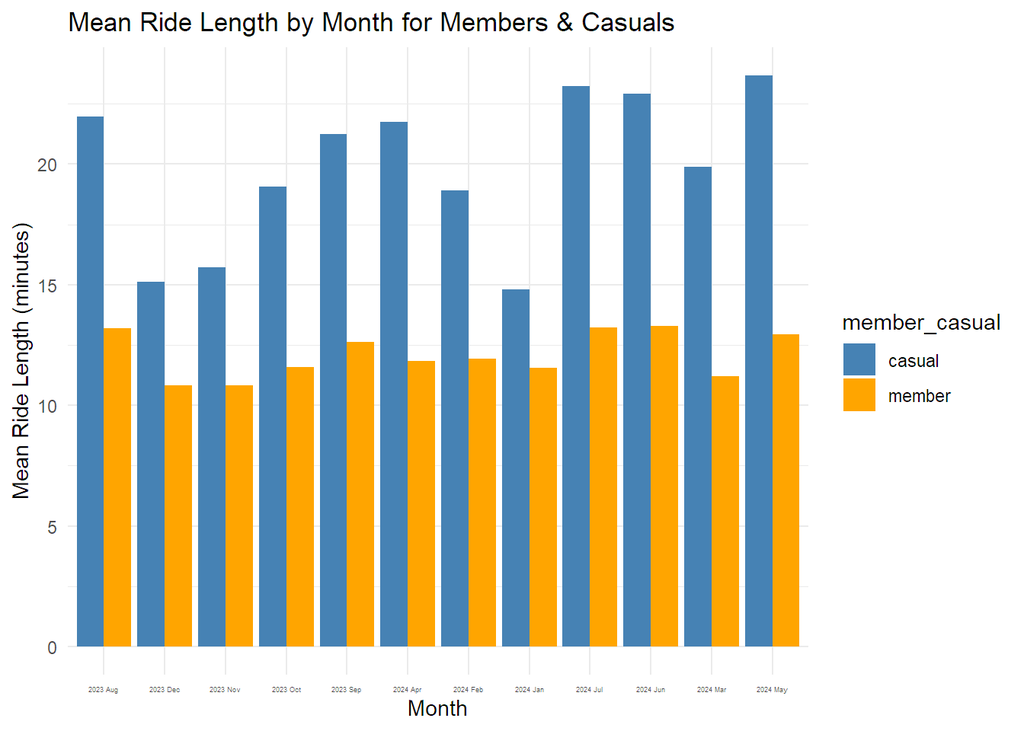

```r
summary_by_ym$year_month <- factor(summary_by_ym$year_month, levels = unique(summary_by_ym$year_month))

ggplot(summary_by_ym, aes(x = year_month, y = mean_rides, fill = member_casual)) +
  geom_col(position = "dodge") +
  labs(x = "Month", y = "Mean Ride Length (minutes)",
       title = "Mean Ride Length by Month for Members & Casuals") +
  scale_fill_manual(values = c("steelblue", "orange")) +
  theme_minimal() +
  theme(axis.text.x = element_text(size = 3.5))
```

#5. Conclusions #This analysis provided insights into the ride-sharing behavior of members and casual users over the period from August 2023 to July 2024.

#6. Visualizations

# 7. Recommendations

##Based on the analysis: ###Marketing Campaigns: Focus on casual users during weekends and peak months to capitalize on their longer ride durations. ###Membership Incentives: Introduce membership incentives to convert casual users into members, potentially balancing the ride distribution throughout the week. ###Operational Adjustments: Optimize bike availability and station management during peak times for both members and casual users.

[output not shown]